# [TWD] Praca Domowa 5

Bartlomiej Granat

20.11.2018

# Wstęp

W ramach pracy domowej nr. 5 postanowiłem zbadać czytelność wykresów kołowych 3D. Poprosiłem ankietowanych o zadecydowanie, która część wykresu jest większa. Obie były równe, jednak z powodu złego przedstawienia danych osoba oglądająca wykres potrzebuje więcej czasu na podjęcie decyzji i często wskazuje złą odpowiedź.

# Wykresy i wyniki ankiety

W pierwszym pytaniu badam odbiór danych na wykresie 3D. Jak widać po wynikach prawie połowa ankietowanych zostało wprowadzonych w błąd przez głębię wykresu.

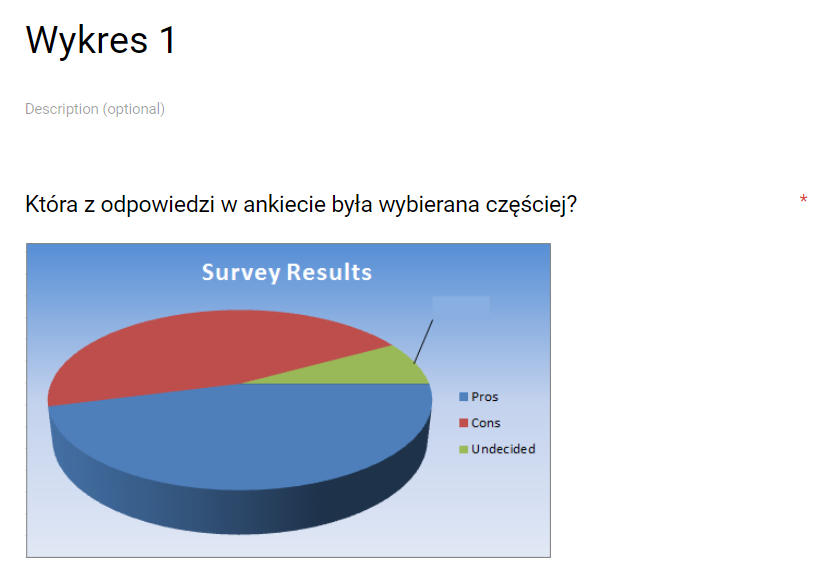

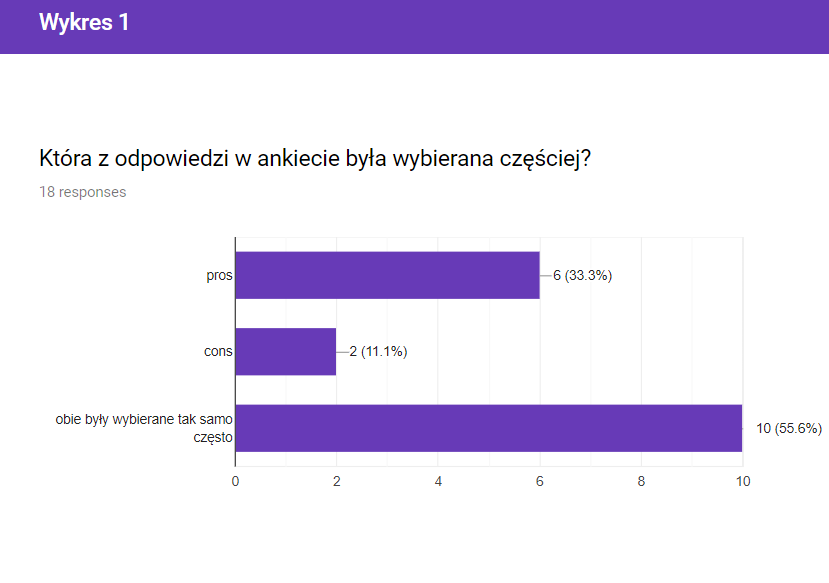

W drugim pytaniu również został przedstawiony kołowy wykres 3D, jednak zielony fragment został umieszczony w innym miejscu co także powoduje złudzenie optyczne. Znów wyniki ankiety pokazują, że nie łatwo jest jednoznacznie określić dokładne wyniki ankiety.

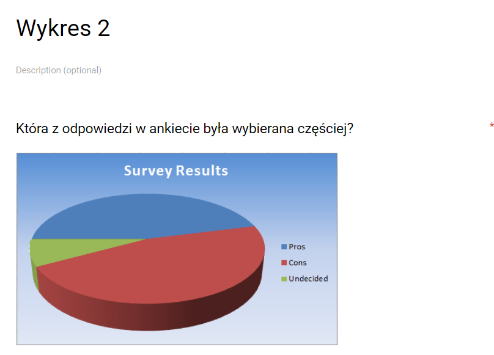

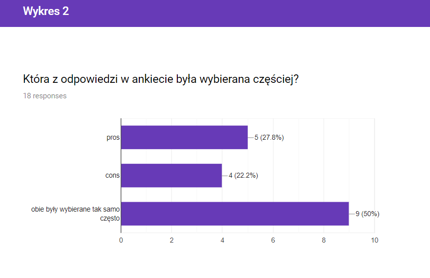

Jako trzeci został przedstawiony wykres kołowy 2D widzimy, że nadal nie jest tak łatwo porównać poszczególne części. Jednak więcej osób było w stanie wskazać prawidłową odpowiedź.

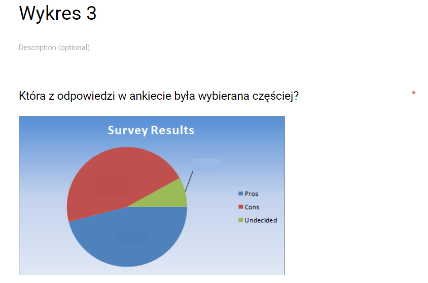

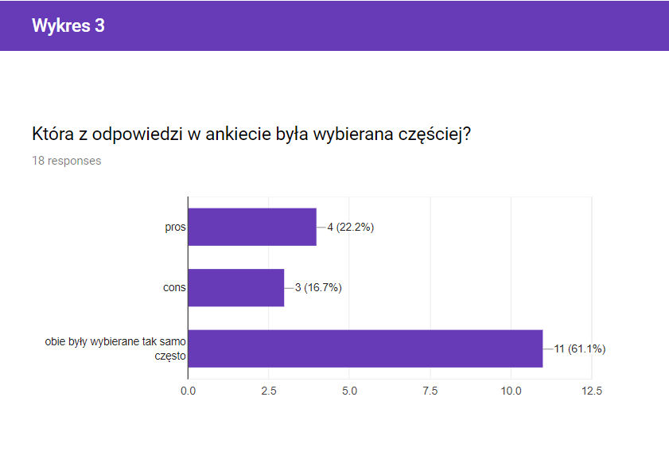

Jako czwarty przedstawiłem zrobiony przez siebie wykres słupkowy dla tych samych danych. Wyraźnie widać, że jest to najlepsza forma przedstawienie danych i praktycznie wszyscy prawidłowo wskazali odpowiedź

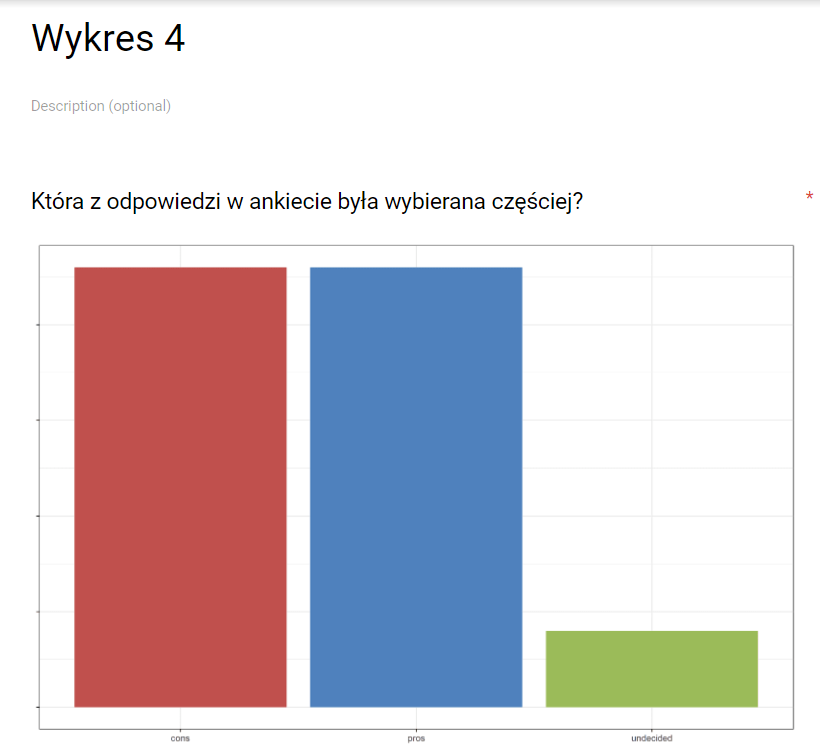

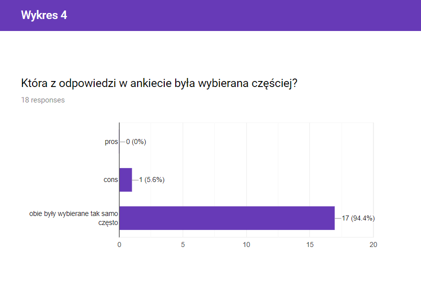

Wnioskując z wyników ankiety wykresy kołowe nie są odpowiednim sposobem przedstawiania danych.